# Microglia_monocyte_comparisons_ranking_400

### + cultured monocytes

```r
overlap_cultured_monocytes <- merge(migasti_unstim, cultured_monocytes, by = "symbol")
percentage_migasti_cultured_monocytes = length(overlap_cultured_monocytes$symbol)/length(migasti_unstim$symbol)*100
percentage_migasti_cultured_monocytes
```

[1] 34.5

```r
list(overlap_cultured_monocytes$symbol)
```

[[1]] [1] “ACTB” “ACTG1” “ACTR3” “ALDOA” “ANXA2” “ANXA5”  
[7] “ARID5B” “ARPC1B” “ARPC2” “ARPC5” “ARRDC3” “ASAH1”  
[13] “ATP6AP2” “ATP6V1A” “ATP6V1B2” “B2M” “C6orf62” “CALM1”  
[19] “CALM2” “CANX” “CAP1” “CAPG” “CAPZA1” “CD14”  
[25] “CD44” “CD63” “CD68” “CD74” “CDC42” “CFL1”  
[31] “CFLAR” “CLTC” “CMTM6” “CORO1C” “CSF1R” “CSNK1A1”  
[37] “CSTB” “CTNNB1” “CTSB” “CTSD” “CTSH” “CXCL16”  
[43] “DDX5” “EEF1A1” “EIF4G2” “ENO1” “FCER1G” “FCGR2A”  
[49] “FERMT3” “FLNA” “FTH1” “FTL” “GABARAP” “GAPDH”  
[55] “GLUL” “GPX1” “GRN” “H3F3B” “HIF1A” “HLA-A”  
[61] “HLA-B” “HLA-C” “HLA-DRA” “HLA-DRB1” “HLA-E” “HNRNPA2B1” [67] “HNRNPK” “HNRNPU” “HSP90AA1” “HSP90AB1” “HSP90B1” “HSPA5”  
[73] “HSPA8” “IFI30” “ITGB2” “KYNU” “LAPTM5” “LCP1”  
[79] “LGALS3” “LHFPL2” “MALAT1” “MGAT1” “MSN” “MT-ATP6”  
[85] “MT-CO1” “MT-CO2” “MT-CO3” “MT-CYB” “MT-ND1” “MT-ND2”  
[91] “MT-ND4” “MT-ND5” “MT-RNR1” “MT-RNR2” “MYL6” “NAMPT”  
[97] “NCOA4” “OAZ1” “OLR1” “P4HB” “PDIA3” “PFN1”  
[103] “PGD” “PKM” “PLD3” “PLEKHB2” “PRDX1” “PSAP”  
[109] “PTMA” “PTPRE” “RAB1A” “RBM39” “RHOA” “S100A11”  
[115] “SAT1” “SDCBP” “SEC61A1” “SGK1” “SH3BGRL3” “SLAMF7”  
[121] “SOD2” “SQSTM1” “SRSF3” “TALDO1” “TLN1” “TMBIM6”  
[127] “TMSB4X” “TNFRSF1B” “TPM3” “TPT1” “TUBA1B” “TXNRD1”  
[133] “TYROBP” “UBC” “VIM” “WTAP” “YWHAB” “YWHAZ”

### + macrophages

```r
overlap_macrophages <- merge(migasti_unstim, macrophages, by = "symbol")
percentage_migasti_macrophages = length(overlap_macrophages$symbol)/length(migasti_unstim$symbol)*100
percentage_migasti_macrophages
```

[1] 29.75

```r
list(overlap_macrophages$symbol)
```

[[1]] [1] “ACSL1” “ACTB” “ACTG1” “ACTR3” “ALDOA” “ANXA2”  
[7] “ANXA5” “APOE” “ARF1” “ARPC1B” “ARPC2” “ASAH1”  
[13] “ATP6V1B2” “B2M” “CALM1” “CANX” “CAP1” “CAPG”  
[19] “CD164” “CD44” “CD53” “CD63” “CD74” “CFL1”  
[25] “CLIC1” “CLTC” “CNBP” “CORO1C” “CSDE1” “CSTB”  
[31] “CTNNB1” “CTSB” “CTSD” “CTSH” “CTSL” “CXCL16”  
[37] “DDX3X” “DDX5” “DNAJA1” “EEF1A1” “EIF1” “EIF4G2”  
[43] “ENO1” “FCER1G” “FCGR2A” “FLNA” “FTH1” “FTL”  
[49] “GAPDH” “GLUL” “GRN” “HLA-A” “HLA-B” “HLA-C”  
[55] “HLA-DRA” “HLA-DRB1” “HLA-E” “HNRNPA2B1” “HSP90AA1” “HSP90AB1” [61] “HSP90B1” “HSPA5” “HSPA8” “INHBA” “ITGB2” “LAPTM5”  
[67] “LCP1” “LGALS3” “LITAF” “LPL” “MALAT1” “MGAT1”  
[73] “MSN” “MYL12A” “MYL6” “NCL” “NCOA4” “OAZ1”  
[79] “OLR1” “P4HB” “PFN1” “PGD” “PGK1” “PKM”  
[85] “PLD3” “PLEKHB2” “PLIN2” “PRDX1” “PSAP” “RAB7A”  
[91] “RACK1” “RHOA” “RPL13A” “RPL3” “RPL8” “RPS11”  
[97] “RPS6” “S100A11” “SAT1” “SDCBP” “SH3BGRL3” “SLC11A1”  
[103] “SOD2” “SQSTM1” “SRGN” “TLN1” “TMBIM6” “TMSB10”  
[109] “TMSB4X” “TPM3” “TPT1” “TUBA1B” “TUBB” “TYROBP”  
[115] “UBB” “UBC” “VIM” “WDR1” “YWHAB”

### + ex vivo Gosselin

```r
overlap_microglia_EV_Gosselin <- merge(migasti_unstim, microglia_EV_Gosselin, by = "symbol")
percentage_migasti_EV_Gosselin = length(overlap_microglia_EV_Gosselin$symbol)/length(migasti_unstim$symbol)*100
percentage_migasti_EV_Gosselin
```

[1] 25.25

```r
list(overlap_microglia_EV_Gosselin$symbol)
```

[[1]] [1] “A2M” “ACTB” “ACTG1” “APOE” “ASAH1” “ATP6V1B2” [7] “B2M” “C6orf62” “CANX” “CAP1” “CCL3” “CCL3L1”  
[13] “CCL4” “CCL4L2” “CCNL1” “CD14” “CD164” “CD53”  
[19] “CD68” “CD74” “CD83” “CDKN1A” “CFL1” “CLK1”  
[25] “CLTC” “CREG1” “CSF1R” “CTSB” “CTSD” “CXCL16”  
[31] “DDX3X” “DDX5” “DNAJB1” “DUSP1” “EGR1” “EIF1”  
[37] “EIF4G2” “ETS2” “FOS” “FTH1” “FTL” “GAPDH”  
[43] “GLUL” “GPX1” “GRN” “H3F3B” “HAVCR2” “HERPUD1”  
[49] “HIF1A” “HLA-A” “HLA-B” “HLA-C” “HLA-DRA” “HLA-DRB1” [55] “HLA-E” “HNRNPA2B1” “HNRNPU” “HSP90AA1” “HSP90AB1” “HSP90B1”  
[61] “HSPA1A” “HSPA1B” “HSPA5” “HSPA8” “IER2” “IER3”  
[67] “IL10RA” “ITGB2” “JUNB” “KLF6” “LAPTM5” “LCP1”  
[73] “LHFPL2” “MALAT1” “MGAT1” “MSN” “NCOA4” “NR4A1”  
[79] “OAZ1” “OGFRL1” “OLR1” “PADI2” “PFKFB3” “PLD3”  
[85] “PSAP” “RGS1” “SAT1” “SERPINB9” “SETX” “SGK1”  
[91] “SLC11A1” “SLC38A2” “SPP1” “SRGN” “TLN1” “TLR2”  
[97] “TMBIM6” “TNFRSF1B” “TPT1” “UBC” “ZFP36”

### + in vitro Gosselin

```r
overlap_microglia_IV_Gosselin <- merge(migasti_unstim, microglia_IV_Gosselin, by = "symbol")
percentage_migasti_IV_Gosselin = length(overlap_microglia_IV_Gosselin$symbol)/length(migasti_unstim$symbol)*100
percentage_migasti_IV_Gosselin
```

[1] 40.5

```r
list(overlap_microglia_IV_Gosselin$symbol)
```

[[1]] [1] “A2M” “ACSL1” “ACTB” “ACTG1” “ACTR3” “AKR1B1”  
[7] “ALDOA” “ANXA2” “ANXA5” “APOE” “ARF1” “ARPC1B”  
[13] “ARPC2” “ARPC5” “ASAH1” “ATP6AP2” “ATP6V1B2” “B2M”  
[19] “BCAT1” “CALM1” “CANX” “CAP1” “CAPG” “CCL2”  
[25] “CCL3” “CCL3L1” “CCL4” “CCL4L2” “CD14” “CD164”  
[31] “CD44” “CD53” “CD59” “CD63” “CD68” “CD74”  
[37] “CD83” “CDKN1A” “CFL1” “CHI3L1” “CLIC1” “CLTC”  
[43] “CORO1C” “CREG1” “CSDE1” “CSF1R” “CSTB” “CTNNB1”  
[49] “CTSB” “CTSD” “CTSH” “CTSL” “CXCL16” “CXCL8”  
[55] “DDX3X” “DDX5” “EIF4A1” “EIF4G2” “ENO1” “ETS2”  
[61] “FCER1G” “FERMT3” “FLNA” “FTH1” “FTL” “GABARAP”  
[67] “GAPDH” “GLUL” “GPX1” “GRN” “HAVCR2” “HIF1A”  
[73] “HLA-A” “HLA-B” “HLA-C” “HLA-E” “HM13” “HMOX1”  
[79] “HNRNPA2B1” “HNRNPU” “HSP90AA1” “HSP90AB1” “HSP90B1” “HSPA5”  
[85] “HSPA8” “IER3” “IFI30” “IL10RA” “IL1B” “ITGB2”  
[91] “IVNS1ABP” “KLF6” “LAPTM5” “LCP1” “LDHA” “LGALS1”  
[97] “LHFPL2” “LITAF” “LPL” “MALAT1” “MGAT1” “MMP9”  
[103] “MSN” “MYL12A” “MYL6” “NCOA4” “NINJ1” “NPC1”  
[109] “OAZ1” “OGFRL1” “OLR1” “P4HB” “PADI2” “PFKFB3”  
[115] “PFN1” “PGD” “PGK1” “PKM” “PLAUR” “PLD3”  
[121] “PLEK” “PLEKHB2” “PLEKHO2” “PLIN2” “PRDX1” “PSAP”  
[127] “PTPRE” “RAB7A” “RACK1” “RHOA” “S100A11” “SAT1”  
[133] “SDCBP” “SERF2” “SGK1” “SH3BGRL3” “SLC11A1” “SLC38A2”  
[139] “SOAT1” “SOD2” “SPP1” “SQSTM1” “SRGN” “TIMP1”  
[145] “TLN1” “TLR2” “TMBIM6” “TMSB10” “TMSB4X” “TNFRSF1B” [151] “TPM3” “TPT1” “TUBA1B” “TUBB” “TYMP” “TYROBP”  
[157] “UBC” “VCP” “VIM” “WDR1” “YWHAB” “ZFP36”

### + monocytes Gosselin

```r
overlap_microglia_mono_Gosselin <- merge(migasti_unstim, monocytes_Gosselin, by = "symbol")
percentage_migasti_mono_Gosselin = length(overlap_microglia_mono_Gosselin$symbol)/length(migasti_unstim$symbol)*100
percentage_migasti_mono_Gosselin
```

[1] 29.25

```r
list(overlap_microglia_mono_Gosselin$symbol)
```

[[1]] [1] “ACSL1” “ACTB” “ACTG1” “ALDOA” “ARF1” “ARPC1B”  
[7] “ARPC2” “ASAH1” “ATP6V1B2” “B2M” “BTG1” “CALM2”  
[13] “CANX” “CAP1” “CD14” “CD164” “CD44” “CD53”  
[19] “CD68” “CD74” “CFL1” “CFLAR” “CLIC1” “CNBP”  
[25] “CSDE1” “CSF1R” “CTSB” “CTSD” “DAZAP2” “DDX3X”  
[31] “DDX5” “DUSP1” “DUSP6” “EEF1A1” “EIF1” “EIF4G2”  
[37] “ENO1” “FCER1G” “FERMT3” “FLNA” “FOS” “FTH1”  
[43] “FTL” “GABARAP” “GAPDH” “GLUL” “GPX1” “GRN”  
[49] “H3F3B” “HLA-A” “HLA-B” “HLA-C” “HLA-DRA” “HLA-DRB1” [55] “HLA-E” “HNRNPA2B1” “HSPA8” “IER2” “IFI30” “IL10RA”  
[61] “ITGB2” “JUNB” “KLF6” “LAPTM5” “LCP1” “MALAT1”  
[67] “MGAT1” “MMP9” “MSN” “MYL6” “NACA” “NCOA4”  
[73] “OAZ1” “OGFRL1” “P4HB” “PFN1” “PGD” “PGK1”  
[79] “PKM” “PLD3” “PSAP” “RACK1” “RGS2” “RHOA”  
[85] “RPL13A” “RPL15” “RPL3” “RPL8” “RPLP1” “RPS11”  
[91] “RPS14” “RPS3” “RPS6” “S100A11” “S100A8” “SAT1”  
[97] “SDCBP” “SERF2” “SH3BGRL3” “SLC11A1” “SOD2” “SRGN”  
[103] “TALDO1” “TLN1” “TLR2” “TMBIM6” “TMSB10” “TMSB4X”  
[109] “TNFRSF1B” “TPT1” “TYMP” “TYROBP” “UBC” “VIM”  
[115] “WDR1” “YWHAB” “ZFP36”

# percentage between datasets

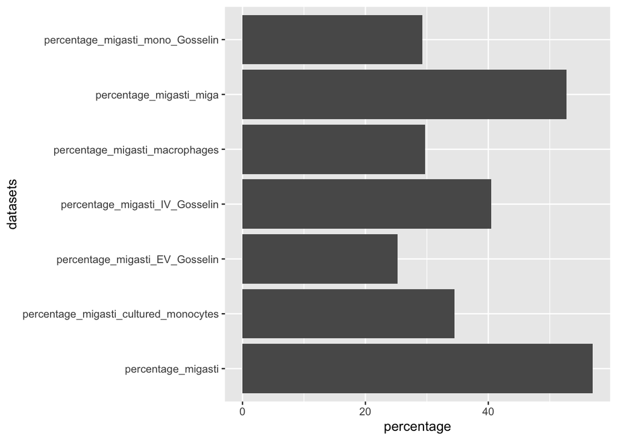

```r
percentage <- rbind(percentage_migasti_miga, percentage_migasti, percentage_migasti_cultured_monocytes, percentage_migasti_macrophages, percentage_migasti_EV_Gosselin, percentage_migasti_IV_Gosselin, percentage_migasti_mono_Gosselin)

datasets <- rownames(percentage)

percentages <- cbind(datasets, percentage)

p<-ggplot(data=percentages, aes(x=percentage, y=datasets)) +
geom_bar(stat="identity")
p
```